# baseline_immunity

Gabriel Melhado

2026-07-20

```r
# Load packages
pacman::p_load(tidyverse, here, glmmTMB, DHARMa, performance, broom.mixed, car, dplyr, emmeans, ggplot2, patchwork)
```

```r
# Load Data
data <- read.csv(here("data", "exp1_data.csv"))
```

## Explore data distribution

```r
summary(data$total_wbc)
```

```
##    Min. 1st Qu.  Median    Mean 3rd Qu.    Max.
##   17.00   29.00   36.50   39.58   48.25   74.00
```

```r
summary(data$Lymphocyte)
```

```
##    Min. 1st Qu.  Median    Mean 3rd Qu.    Max.
##   33.00   57.75   76.00   70.42   83.00   93.00
```

```r
summary(data$Neutrophil)
```

```
##    Min. 1st Qu.  Median    Mean 3rd Qu.    Max.
##    5.00   16.00   23.00   28.24   41.00   61.00
```

```r
summary(data$Monocyte)
```

```
##    Min. 1st Qu.  Median    Mean 3rd Qu.    Max.    NA's
##   1.000   1.000   2.000   3.057   4.000  13.000      90
```

```r
summary(data$`N-L_ratio`)
```

```
## Length  Class   Mode
##      0   NULL   NULL
```

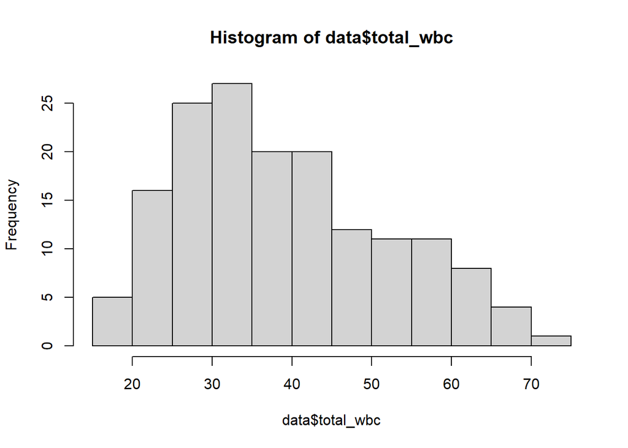

```r
hist(data$total_wbc)
```

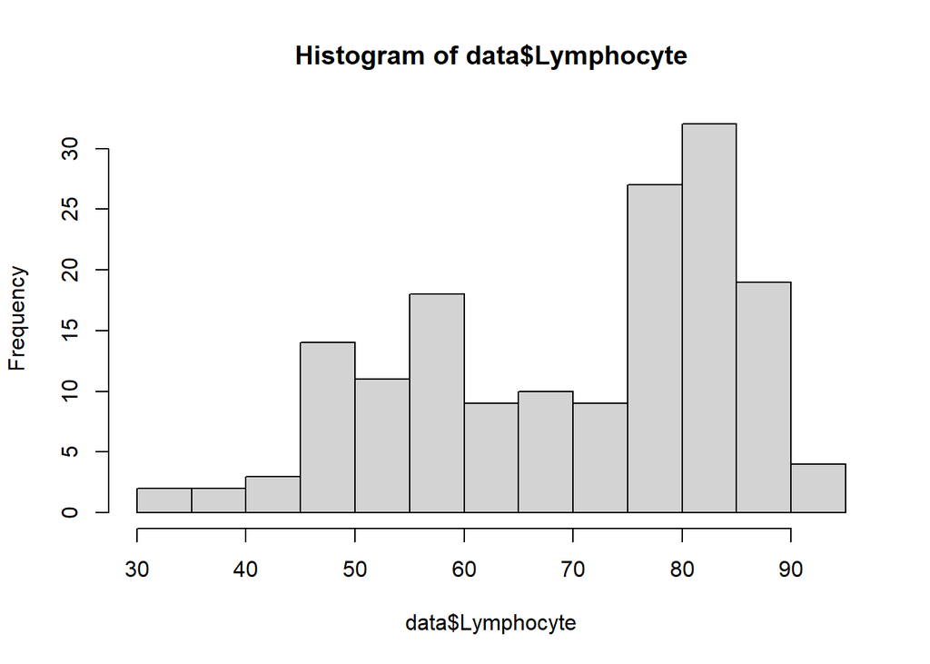

```r
hist(data$Lymphocyte)
```

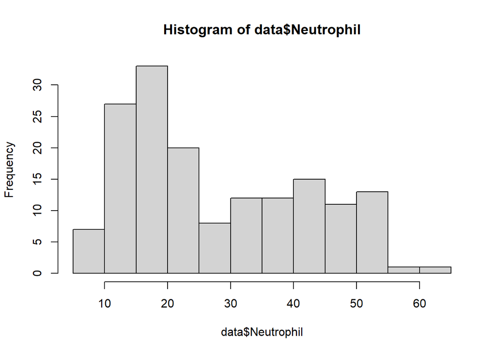

```r
hist(data$Neutrophil)
```

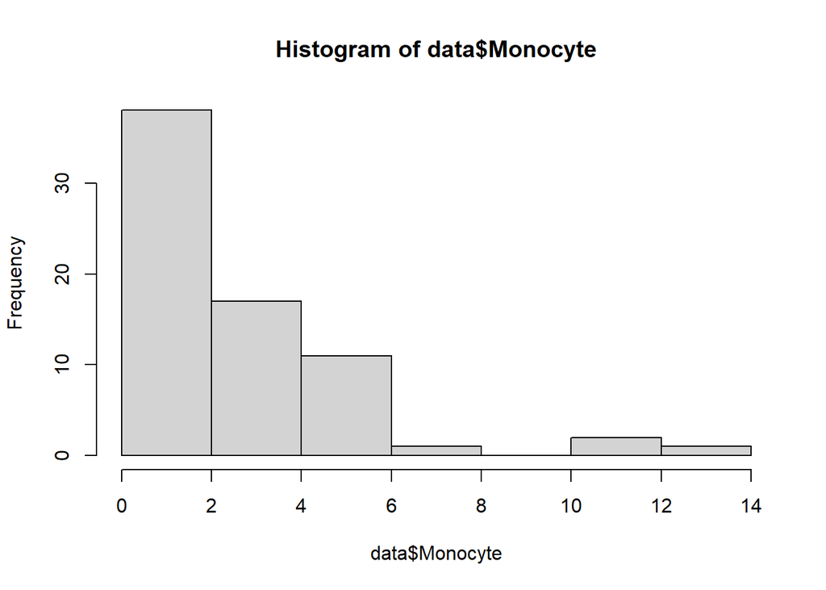

```r
hist(data$Monocyte)
```

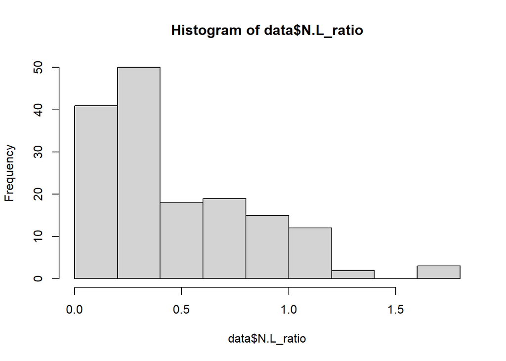

```r
hist(data$`N.L_ratio`)
```

## Quantify the contribution of monocytes

Calculate the percentage of all classified leukocytes represented by monocytes across the dataset. This descriptive calculation is used to determine whether monocytes contribute enough observations to justify a separate inferential analysis.

```r
# percentage of total leukocytes represented by monocytes
# Total leukocytes counted
total_leukocytes <- sum(
  data$Lymphocyte +
  data$Neutrophil +
  data$Monocyte,
  na.rm = TRUE
)

# Percentage of monocytes
monocyte_percent <- sum(data$Monocyte, na.rm = TRUE) /
  total_leukocytes * 100

monocyte_percent
```

```
## [1] 3.05758
```

## Analyse total white blood cell (WBC) count

Describe total white blood cell counts, apply a square-root transformation to reduce skewness, and fit a Gaussian mixed-effects model testing the effect of fluoxetine treatment while controlling for body mass. Tank identity is included as a random intercept to account for non-independence among fish housed in the same tank. Model assumptions are evaluated using simulated residuals, followed by an omnibus treatment test and Tukey-adjusted pairwise comparisons.

```r
#WBC
mean(data$total_wbc)
```

```
## [1] 39.58125
```

```r
var(data$total_wbc)
```

```
## [1] 172.6349
```

```r
sd(data$total_wbc)
```

```
## [1] 13.13906
```

```r
#square root
data$sqrt_total_wbc <- sqrt(data$total_wbc)

#Model
m_wbc <- glmmTMB(
  sqrt_total_wbc ~ Treatment + Body_mass + (1|Tank_ID),
  family = gaussian(),
  data = data
)

summary(m_wbc)
```

```
##  Family: gaussian  ( identity )
## Formula:          sqrt_total_wbc ~ Treatment + Body_mass + (1 | Tank_ID)
## Data: data
##
##      AIC      BIC   logLik deviance df.resid
##    401.6    420.0   -194.8    389.6      154
##
## Random effects:
##
## Conditional model:
##  Groups   Name        Variance Std.Dev.
##  Tank_ID  (Intercept) 0.1565   0.3955
##  Residual             0.5720   0.7563
## Number of obs: 160, groups:  Tank_ID, 24
##
## Dispersion estimate for gaussian family (sigma^2): 0.572
##
## Conditional model:
##               Estimate Std. Error z value Pr(>|z|)
## (Intercept)     7.2912     0.2576  28.307  < 2e-16 ***
## TreatmentHigh  -1.3588     0.2462  -5.519 3.40e-08 ***
## TreatmentLow   -0.9921     0.2461  -4.031 5.56e-05 ***
## Body_mass      -0.5029     0.3178  -1.583    0.114
## ---
## Signif. codes:  0 '***' 0.001 '**' 0.01 '*' 0.05 '.' 0.1 ' ' 1
```

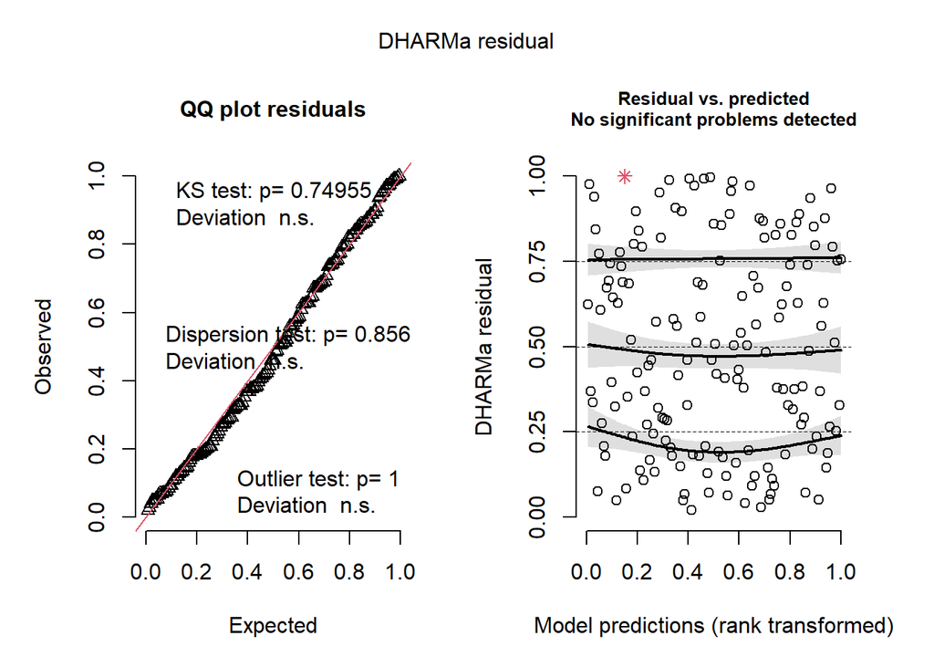

```r
res_wbc <- simulateResiduals(m_wbc)
plot(res_wbc)
```

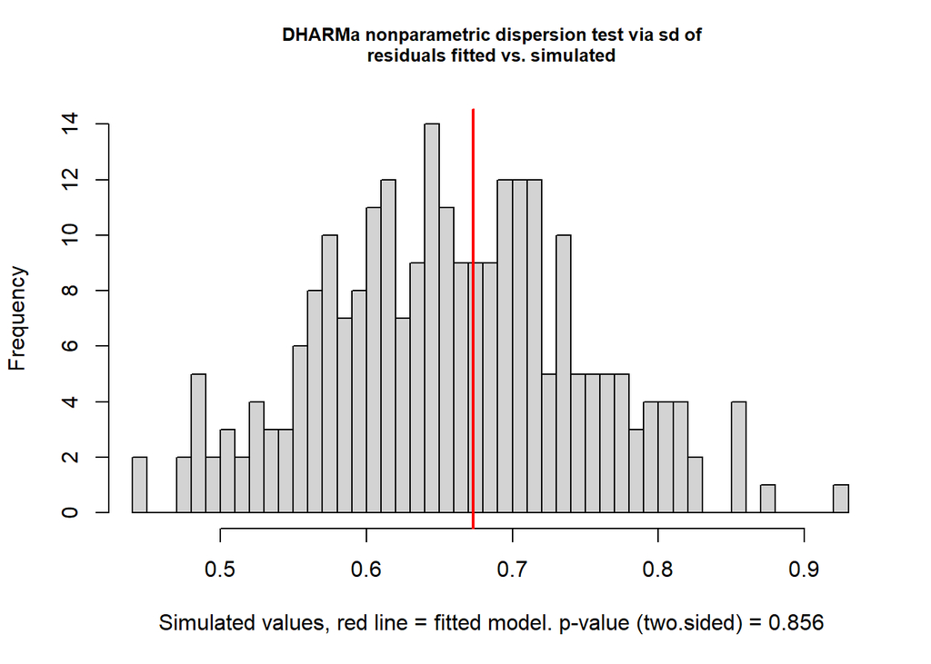

```
##
##  DHARMa nonparametric dispersion test via sd of residuals fitted vs.
##  simulated
##
## data:  simulationOutput
## dispersion = 1.0225, p-value = 0.856
## alternative hypothesis: two.sided
```

```r
testDispersion(res_wbc)
```

```r
Anova (m_wbc)
```

```
## Analysis of Deviance Table (Type II Wald chisquare tests)
##
## Response: sqrt_total_wbc
##             Chisq Df Pr(>Chisq)
## Treatment 32.6413  2  8.167e-08 ***
## Body_mass  2.5044  1     0.1135
## ---
## Signif. codes:  0 '***' 0.001 '**' 0.01 '*' 0.05 '.' 0.1 ' ' 1
```

```r
emm_wbc <- emmeans(m_wbc, ~ Treatment)

pairs(emm_wbc, adjust = "tukey")
```

```
##  contrast       estimate    SE  df t.ratio p.value
##  Control - High    1.359 0.246 154   5.519  <.0001
##  Control - Low     0.992 0.246 154   4.031  0.0003
##  High - Low       -0.367 0.247 154  -1.487  0.2998
##
## P value adjustment: tukey method for comparing a family of 3 estimates
```

## Plot total white blood cell count

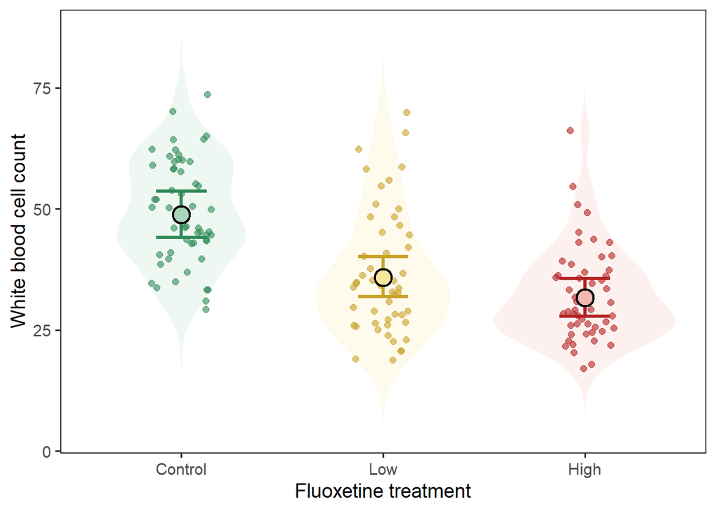

```r
# Set treatment order
data <- data %>%
  mutate(
    Treatment = factor(
      Treatment,
      levels = c("Control", "Low", "High")
    )
  )

# 2) Refit model with updated Treatment factor
m_wbc <- glmmTMB(
  sqrt_total_wbc ~ Treatment + Body_mass + (1 | Tank_ID),
  family = gaussian(),
  data = data
)

# 3) Estimated marginal means
emm_wbc <- emmeans(m_wbc, ~ Treatment)

emm_df <- as.data.frame(emm_wbc)

# 4) Back-transform estimates to original WBC scale
emm_df <- emm_df %>%
  mutate(
    mean_wbc  = emmean^2,
    lower_wbc = lower.CL^2,
    upper_wbc = upper.CL^2
  )

# 5) Colour palettes
pastel_cols <- c(
  "Control" = "#A8D5BA",
  "Low"     = "#F9E79F",
  "High"    = "#F5B7B1"
)

dark_cols <- c(
  "Control" = "#2E8B57",
  "Low"     = "#C9A227",
  "High"    = "#B22222"
)

# 6) Plot
p_wbc <- ggplot() +

  geom_violin(
    data = data,
    aes(x = Treatment, y = total_wbc, fill = Treatment),
    alpha = 0.20,
    colour = NA,
    trim = FALSE
  ) +

  geom_jitter(
    data = data,
    aes(x = Treatment, y = total_wbc, colour = Treatment),
    width = 0.15,
    alpha = 0.6,
    size = 2
  ) +

  geom_errorbar(
    data = emm_df,
    aes(
      x = Treatment,
      ymin = lower_wbc,
      ymax = upper_wbc,
      colour = Treatment
    ),
    width = 0.25,
    linewidth = 1.2
  ) +

  geom_point(
    data = emm_df,
    aes(
      x = Treatment,
      y = mean_wbc,
      fill = Treatment
    ),
    shape = 21,
    size = 5,
    stroke = 1.2,
    colour = "black"
  ) +

  scale_colour_manual(values = dark_cols) +
  scale_fill_manual(values = pastel_cols) +

  theme_bw(base_size = 14) +

  labs(
    x = "Fluoxetine treatment",
    y = "White blood cell count"
  ) +

  theme(
    panel.grid = element_blank(),
    legend.position = "none"
  )

# Display plot
p_wbc
```

```r
# 7) Save figure
ggsave(
  filename = here::here("figures", "total_wbc.pdf"),
  plot = p_wbc,
  width = 6,
  height = 5
)

ggsave(
  filename = here::here("figures", "total_wbc.jpg"),
  plot = p_wbc,
  width = 6,
  height = 5,
  dpi = 600
)
```

## Analyse the neutrophil-to-lymphocyte ratio

Summarise the neutrophil-to-lymphocyte ratio, log-transform it to improve model fit, and test treatment effects with a Gaussian mixed-effects model that includes body mass and tank identity. Residual diagnostics, an omnibus treatment test, and Tukey-adjusted pairwise comparisons are used to evaluate model adequacy and treatment differences.

```r
#N/L ratio
mean(data$N.L_ratio)
```

```
## [1] 0.4754662
```

```r
var(data$N.L_ratio)
```

```
## [1] 0.132432
```

```r
sd(data$N.L_ratio)
```

```
## [1] 0.3639121
```

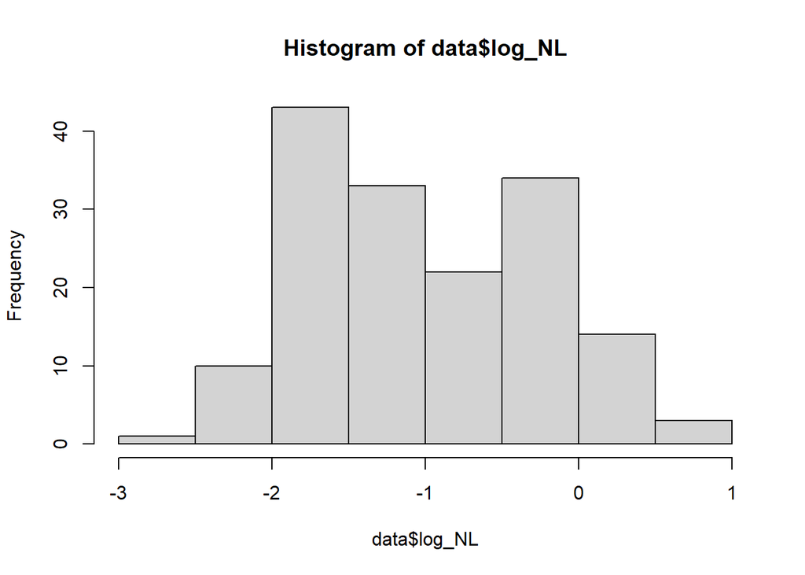

```r
data$log_NL <- log(data$N.L_ratio)
hist(data$log_NL)
```

```r
#Model
m_NL <- glmmTMB(
  log_NL ~ Treatment + Body_mass + (1|Tank_ID),
  family = gaussian(),
  data = data
)

summary(m_NL)
```

```
##  Family: gaussian  ( identity )
## Formula:          log_NL ~ Treatment + Body_mass + (1 | Tank_ID)
## Data: data
##
##      AIC      BIC   logLik deviance df.resid
##    214.5    233.0   -101.3    202.5      154
##
## Random effects:
##
## Conditional model:
##  Groups   Name        Variance Std.Dev.
##  Tank_ID  (Intercept) 0.02099  0.1449
##  Residual             0.19124  0.4373
## Number of obs: 160, groups:  Tank_ID, 24
##
## Dispersion estimate for gaussian family (sigma^2): 0.191
##
## Conditional model:
##               Estimate Std. Error z value Pr(>|z|)
## (Intercept)    -1.4434     0.1326 -10.886   <2e-16 ***
## TreatmentLow    1.3370     0.1114  11.998   <2e-16 ***
## TreatmentHigh   0.1528     0.1115   1.371    0.170
## Body_mass      -0.1198     0.1784  -0.672    0.502
## ---
## Signif. codes:  0 '***' 0.001 '**' 0.01 '*' 0.05 '.' 0.1 ' ' 1
```

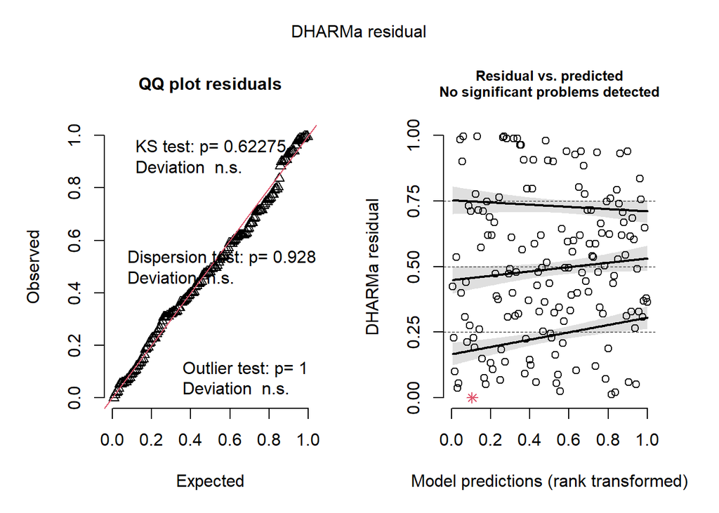

```r
res_NL <- DHARMa::simulateResiduals(m_NL)
plot(res_NL)
```

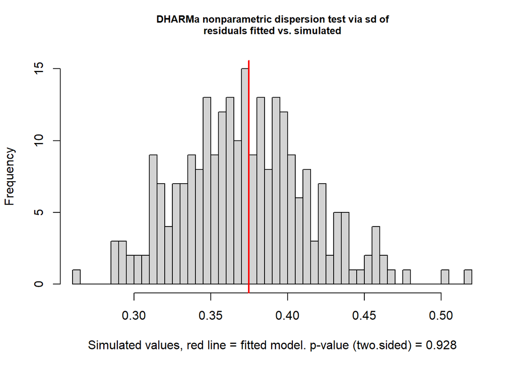

```
##
##  DHARMa nonparametric dispersion test via sd of residuals fitted vs.
##  simulated
##
## data:  simulationOutput
## dispersion = 1.006, p-value = 0.928
## alternative hypothesis: two.sided
```

```r
DHARMa::testDispersion(res_NL)
```

```r
Anova(m_NL)
```

```
## Analysis of Deviance Table (Type II Wald chisquare tests)
##
## Response: log_NL
##              Chisq Df Pr(>Chisq)
## Treatment 172.0721  2     <2e-16 ***
## Body_mass   0.4514  1     0.5017
## ---
## Signif. codes:  0 '***' 0.001 '**' 0.01 '*' 0.05 '.' 0.1 ' ' 1
```

```r
emm_NL <- emmeans(m_NL, ~ Treatment)
pairs(emm_NL, adjust = "tukey")
```

```
##  contrast       estimate    SE  df t.ratio p.value
##  Control - Low    -1.337 0.111 154 -11.998  <.0001
##  Control - High   -0.153 0.111 154  -1.371  0.3587
##  Low - High        1.184 0.112 154  10.599  <.0001
##
## P value adjustment: tukey method for comparing a family of 3 estimates
```

## Plot the neutrophil-to-lymphocyte ratio

```r
# 1) Ensure treatment order BEFORE fitting the model
data$Treatment <- factor(
  data$Treatment,
  levels = c("Control", "Low", "High")
)

# 2) Refit model after setting treatment order
m_NL <- glmmTMB(
  log_NL ~ Treatment + Body_mass + (1 | Tank_ID),
  family = gaussian(),
  data = data
)

# 3) Colours
pastel_cols <- c(
  "Control" = "#A8D5BA",
  "Low"     = "#F9E79F",
  "High"    = "#F5B7B1"
)

dark_cols <- c(
  "Control" = "#2E8B57",
  "Low"     = "#C9A227",
  "High"    = "#B22222"
)

# 4) Get emmeans on log scale and back-transform
emm_NL_df <- emmeans(m_NL, ~ Treatment) %>%
  as.data.frame() %>%
  dplyr::mutate(
    Treatment = factor(Treatment, levels = c("Control", "Low", "High")),
    emmean_bt = exp(emmean),
    lower_bt  = exp(lower.CL),
    upper_bt  = exp(upper.CL)
  )

# Check estimates before plotting
emm_NL_df
```

```
##   Treatment     emmean         SE  df   lower.CL    upper.CL emmean_bt
## 1   Control -1.5165973 0.07860510 154 -1.6718807 -1.36131386 0.2194574
## 2       Low -0.1795823 0.07899276 154 -0.3356315 -0.02353304 0.8356192
## 3      High -1.3637541 0.07901229 154 -1.5198419 -1.20766628 0.2556991
##    lower_bt  upper_bt
## 1 0.1878934 0.2563238
## 2 0.7148865 0.9767417
## 3 0.2187465 0.2988940
```

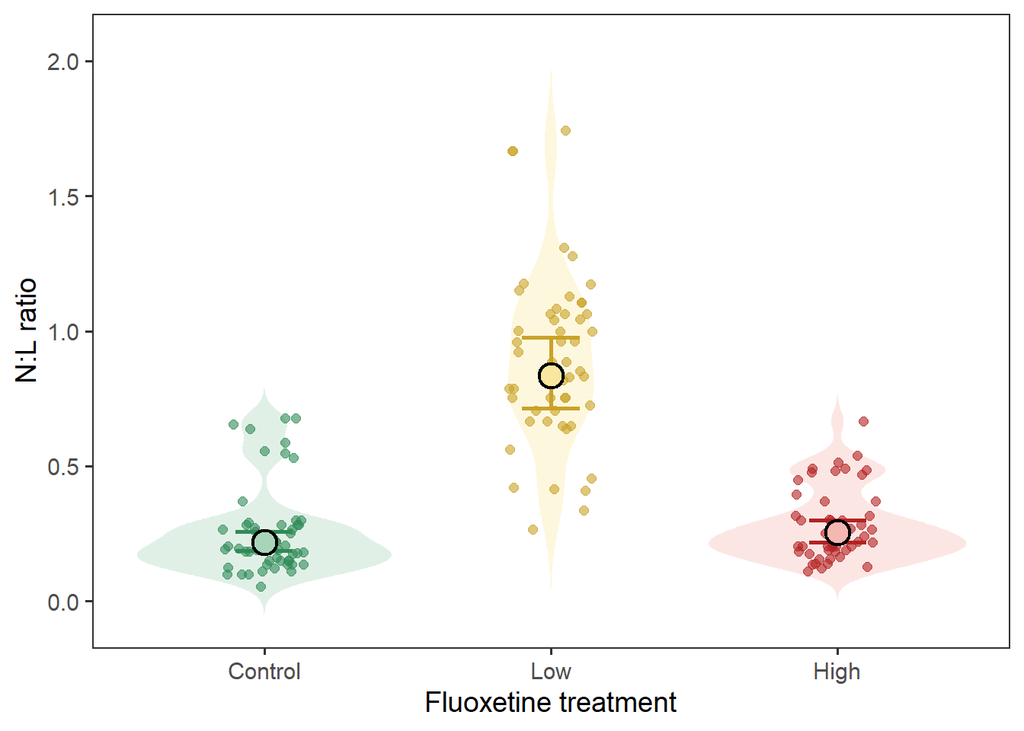

```r
# 5) Plot
p_nl_ratio <- ggplot() +

  geom_violin(
    data = data,
    aes(x = Treatment, y = N.L_ratio, fill = Treatment),
    alpha = 0.35,
    colour = NA,
    trim = FALSE
  ) +

  geom_jitter(
    data = data,
    aes(x = Treatment, y = N.L_ratio, colour = Treatment),
    width = 0.15,
    alpha = 0.6,
    size = 2
  ) +

  geom_errorbar(
    data = emm_NL_df,
    aes(
      x = Treatment,
      ymin = lower_bt,
      ymax = upper_bt,
      colour = Treatment
    ),
    width = 0.2,
    linewidth = 1
  ) +

  geom_point(
    data = emm_NL_df,
    aes(x = Treatment, y = emmean_bt, fill = Treatment),
    shape = 21,
    size = 5,
    stroke = 1.2,
    colour = "black"
  ) +

  scale_fill_manual(values = pastel_cols) +
  scale_colour_manual(values = dark_cols) +

  theme_bw(base_size = 14) +

  labs(
    x = "Fluoxetine treatment",
    y = "N:L ratio"
  ) +

  theme(
    panel.grid = element_blank(),
    legend.position = "none"
  )

p_nl_ratio
```

```r
# Save
ggsave(
  filename = here::here("figures", "nl_ratio.pdf"),
  plot = p_nl_ratio,
  width = 6,
  height = 5
)

ggsave(
  filename = here::here("figures", "nl_ratio.jpg"),
  plot = p_nl_ratio,
  width = 6,
  height = 5,
  dpi = 600
)
```

## Analyse lymphocyte proportions

Analyse lymphocyte proportions to determine whether changes in the neutrophil-to-lymphocyte (N:L) ratio are driven by alterations in lymphocyte abundance. Because the N:L ratio can increase through either a reduction in lymphocytes, an increase in neutrophils, or both, each leukocyte type is analysed separately to identify the cellular mechanism underlying any observed treatment effect. Lymphocyte percentages are modelled as grouped binomial data using a beta-binomial mixed-effects model, with treatment and body mass included as fixed effects and tank included as a random intercept. Residual diagnostics and Tukey-adjusted pairwise comparisons are then used to evaluate treatment differences.

```r
# Lymphocytes
m_lymph_bb <- glmmTMB(
  cbind(Lymphocyte, 100 - Lymphocyte) ~ Treatment + Body_mass + (1|Tank_ID),
  family = betabinomial(link="logit"),
  data = data
)

summary(m_lymph_bb)
```

```
##  Family: betabinomial  ( logit )
## Formula:
## cbind(Lymphocyte, 100 - Lymphocyte) ~ Treatment + Body_mass +
##     (1 | Tank_ID)
## Data: data
##
##      AIC      BIC   logLik deviance df.resid
##   1143.4   1161.8   -565.7   1131.4      154
##
## Random effects:
##
## Conditional model:
##  Groups  Name        Variance Std.Dev.
##  Tank_ID (Intercept) 0.03328  0.1824
## Number of obs: 160, groups:  Tank_ID, 24
##
## Dispersion parameter for betabinomial family (): 41.7
##
## Conditional model:
##               Estimate Std. Error z value Pr(>|z|)
## (Intercept)    1.35289    0.13810   9.796   <2e-16 ***
## TreatmentLow  -1.23451    0.12110 -10.194   <2e-16 ***
## TreatmentHigh -0.11673    0.12530  -0.932    0.352
## Body_mass      0.04028    0.17385   0.232    0.817
## ---
## Signif. codes:  0 '***' 0.001 '**' 0.01 '*' 0.05 '.' 0.1 ' ' 1
```

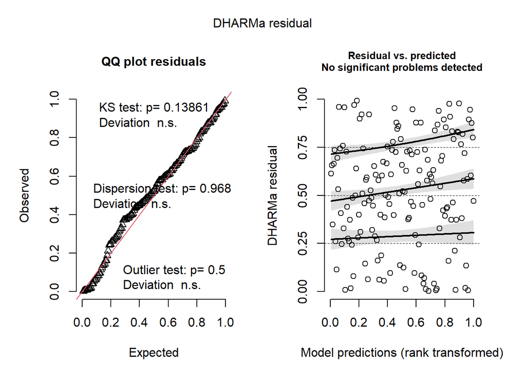

```r
res_lymph_bb <- DHARMa::simulateResiduals(m_lymph_bb)
plot(res_lymph_bb)
```

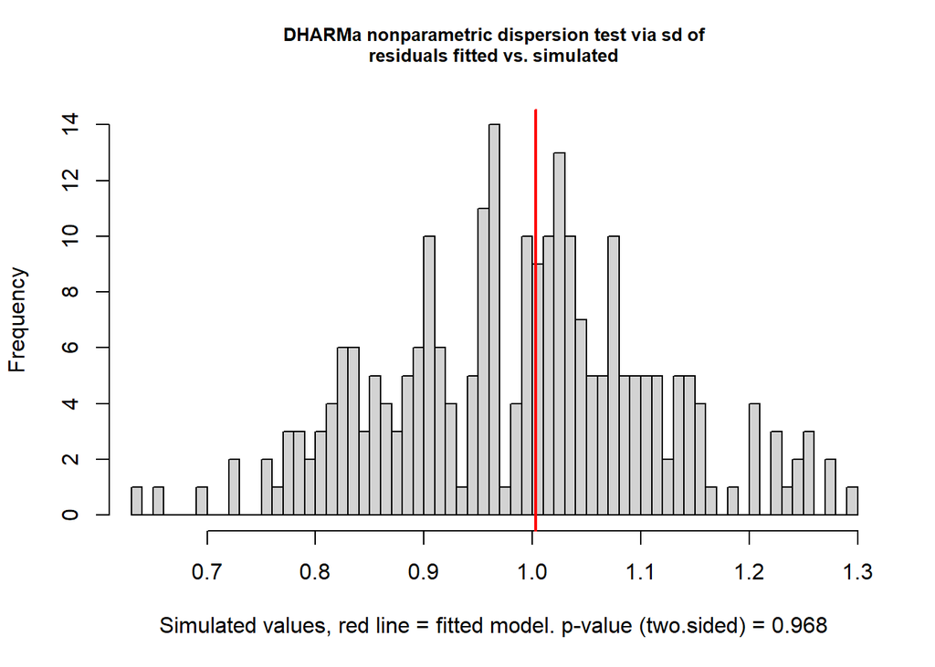

```
##
##  DHARMa nonparametric dispersion test via sd of residuals fitted vs.
##  simulated
##
## data:  simulationOutput
## dispersion = 1.0147, p-value = 0.968
## alternative hypothesis: two.sided
```

```r
DHARMa::testDispersion(res_lymph_bb)
```

```r
Anova(m_lymph_bb)
```

```
## Analysis of Deviance Table (Type II Wald chisquare tests)
##
## Response: cbind(Lymphocyte, 100 - Lymphocyte)
##              Chisq Df Pr(>Chisq)
## Treatment 130.4696  2     <2e-16 ***
## Body_mass   0.0537  1     0.8168
## ---
## Signif. codes:  0 '***' 0.001 '**' 0.01 '*' 0.05 '.' 0.1 ' ' 1
```

```r
emm_lymph <- emmeans(m_lymph_bb, ~ Treatment)
pairs(emm_lymph, adjust = "tukey")
```

```
##  contrast       estimate    SE  df z.ratio p.value
##  Control - Low     1.235 0.121 Inf  10.194  <.0001
##  Control - High    0.117 0.125 Inf   0.932  0.6203
##  Low - High       -1.118 0.120 Inf  -9.279  <.0001
##
## Results are given on the log odds ratio (not the response) scale.
## P value adjustment: tukey method for comparing a family of 3 estimates
```

## Analyse neutrophil proportions

Analyse neutrophil proportions to determine whether changes in the neutrophil-to-lymphocyte (N:L) ratio are driven by increases in neutrophil abundance. Together with the lymphocyte analysis, this allows the biological basis of any treatment-induced changes in the N:L ratio to be identified. Neutrophil percentages are modelled as grouped binomial data using a beta-binomial mixed-effects model, with treatment and body mass included as fixed effects and tank included as a random intercept. Residual diagnostics and Tukey-adjusted pairwise comparisons are then used to evaluate treatment differences.

```r
#Neutrophils
mean(data$Neutrophil)
```

```
## [1] 28.2375
```

```r
var(data$Neutrophil)
```

```
## [1] 203.7923
```

```r
sd(data$Neutrophil)
```

```
## [1] 14.27558
```

```r
# Beta-binomial model
m_neut_bb <- glmmTMB(
  cbind(Neutrophil, 100 - Neutrophil) ~ Treatment + Body_mass + (1|Tank_ID),
  family = betabinomial(link="logit"),
  data = data
)

summary(m_neut_bb)
```

```
##  Family: betabinomial  ( logit )
## Formula:
## cbind(Neutrophil, 100 - Neutrophil) ~ Treatment + Body_mass +
##     (1 | Tank_ID)
## Data: data
##
##      AIC      BIC   logLik deviance df.resid
##   1117.4   1135.9   -552.7   1105.4      154
##
## Random effects:
##
## Conditional model:
##  Groups  Name        Variance Std.Dev.
##  Tank_ID (Intercept) 0.01378  0.1174
## Number of obs: 160, groups:  Tank_ID, 24
##
## Dispersion parameter for betabinomial family (): 46.6
##
## Conditional model:
##               Estimate Std. Error z value Pr(>|z|)
## (Intercept)   -1.42281    0.12517 -11.367   <2e-16 ***
## TreatmentLow   1.25569    0.09745  12.885   <2e-16 ***
## TreatmentHigh  0.13383    0.10297   1.300    0.194
## Body_mass     -0.06098    0.16712  -0.365    0.715
## ---
## Signif. codes:  0 '***' 0.001 '**' 0.01 '*' 0.05 '.' 0.1 ' ' 1
```

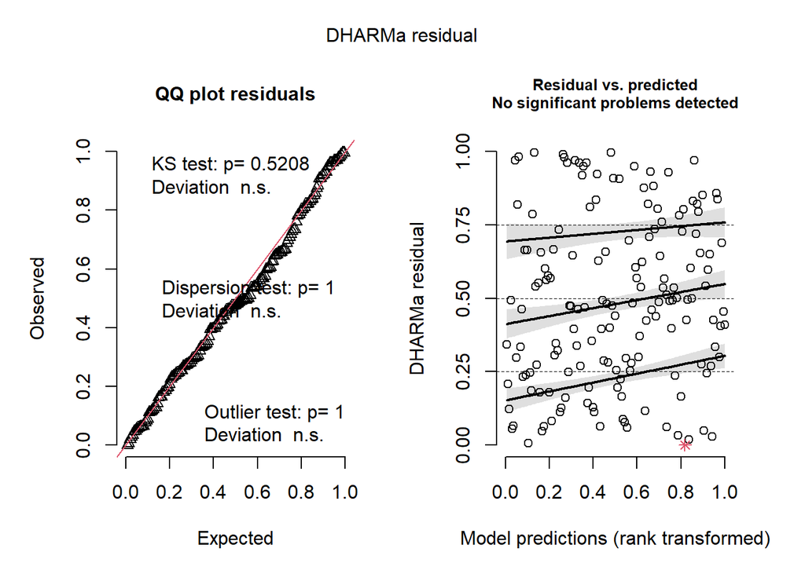

```r
res_neut_bb <- DHARMa::simulateResiduals(m_neut_bb)
plot(res_neut_bb)
```

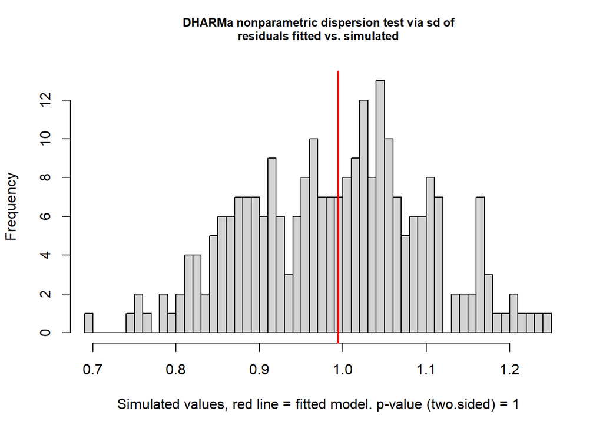

```
##
##  DHARMa nonparametric dispersion test via sd of residuals fitted vs.
##  simulated
##
## data:  simulationOutput
## dispersion = 1.0051, p-value = 1
## alternative hypothesis: two.sided
```

```r
DHARMa::testDispersion(res_neut_bb)
```

```r
Anova(m_neut_bb)
```

```
## Analysis of Deviance Table (Type II Wald chisquare tests)
##
## Response: cbind(Neutrophil, 100 - Neutrophil)
##              Chisq Df Pr(>Chisq)
## Treatment 210.6416  2     <2e-16 ***
## Body_mass   0.1331  1     0.7152
## ---
## Signif. codes:  0 '***' 0.001 '**' 0.01 '*' 0.05 '.' 0.1 ' ' 1
```

```r
emm_lymph <- emmeans(m_neut_bb, ~ Treatment)
pairs(emm_lymph, adjust = "tukey")
```

```
##  contrast       estimate     SE  df z.ratio p.value
##  Control - Low    -1.256 0.0975 Inf -12.885  <.0001
##  Control - High   -0.134 0.1030 Inf  -1.300  0.3953
##  Low - High        1.122 0.0965 Inf  11.630  <.0001
##
## Results are given on the log odds ratio (not the response) scale.
## P value adjustment: tukey method for comparing a family of 3 estimates
```

## Plot lymphocyte and neutrophil proportions

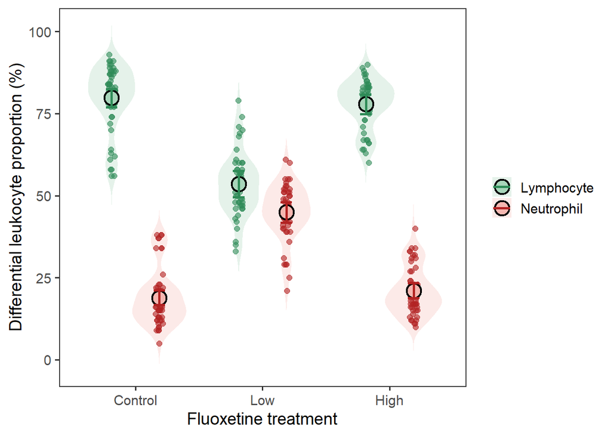

```r
#Plotting Lymphocytes and neutrophils
# Ensure treatment order
data$Treatment <- factor(data$Treatment, levels = c("Control", "Low", "High"))

# ---------------------------
# 1) Long-format raw data
# ---------------------------
raw_long <- data %>%
  select(Treatment, Lymphocyte, Neutrophil) %>%
  pivot_longer(cols = c(Lymphocyte, Neutrophil),
               names_to = "Cell_type",
               values_to = "Percent") %>%
  mutate(Cell_type = factor(Cell_type, levels = c("Lymphocyte", "Neutrophil")))

# ---------------------------
# 2) Back-transformed model means (beta-binomial) -> percent scale
# ---------------------------
emm_lymph <- emmeans(m_lymph_bb, ~ Treatment, type = "response") %>%
  as.data.frame() %>%
  transmute(
    Treatment = factor(Treatment, levels = c("Control", "Low", "High")),
    Cell_type = factor("Lymphocyte", levels = c("Lymphocyte", "Neutrophil")),
    mean_pct  = prob * 100,
    lower_pct = asymp.LCL * 100,
    upper_pct = asymp.UCL * 100
  )

emm_neut <- emmeans(m_neut_bb, ~ Treatment, type = "response") %>%
  as.data.frame() %>%
  transmute(
    Treatment = factor(Treatment, levels = c("Control", "Low", "High")),
    Cell_type = factor("Neutrophil", levels = c("Lymphocyte", "Neutrophil")),
    mean_pct  = prob * 100,
    lower_pct = asymp.LCL * 100,
    upper_pct = asymp.UCL * 100
  )

emm_both <- bind_rows(emm_lymph, emm_neut)

# ---------------------------
# 3) Colours (cell-type mapped)
# ---------------------------
fill_cells <- c(
  "Lymphocyte" = "#A8D5BA",  # pastel green
  "Neutrophil" = "#F5B7B1"   # pastel red
)

dark_cells <- c(
  "Lymphocyte" = "#2E8B57",  # dark green
  "Neutrophil" = "#B22222"   # dark red
)

dodge_w <- 0.75

# ---------------------------
# 4) Plot: side-by-side per treatment
# ---------------------------
p_lymphocyte_neutrophils <- ggplot(raw_long, aes(x = Treatment, y = Percent, fill = Cell_type)) +

  geom_violin(
    position = position_dodge(width = dodge_w),
    alpha = 0.30,
    colour = NA,
    trim = FALSE
  ) +

  geom_jitter(
    aes(colour = Cell_type),
    position = position_jitterdodge(jitter.width = 0.12, dodge.width = dodge_w),
    alpha = 0.6,
    size = 2
  ) +

  # Model means (do NOT inherit Percent mapping)
 geom_point(
  data = emm_both,
  aes(x = Treatment, y = mean_pct, fill = Cell_type),
  shape = 21,
  size = 5,
  stroke = 1.2,
  colour = "black",
  position = position_dodge(width = dodge_w),
  inherit.aes = FALSE
) +

  # 95% CI (do NOT inherit Percent mapping)
  geom_errorbar(
    data = emm_both,
    aes(x = Treatment, ymin = lower_pct, ymax = upper_pct, colour = Cell_type),
    position = position_dodge(width = dodge_w),
    width = 0.18,
    linewidth = 1,
    inherit.aes = FALSE
  ) +

  scale_fill_manual(values = fill_cells) +
  scale_colour_manual(values = dark_cells) +

  theme_bw(base_size = 14) +
  labs(
    x = "Fluoxetine treatment",
    y = "Differential leukocyte proportion (%)") +
  theme(
    plot.title = element_text(hjust = 0.5),
    panel.grid = element_blank(),
    legend.title = element_blank()
  )

print(p_lymphocyte_neutrophils)
```

```r
ggsave(
  filename = here::here("figures", "lymphocytes_neutrophils.pdf"),
  plot = p_lymphocyte_neutrophils,
  width = 6,
  height = 5
)

ggsave(
  filename = here::here("figures", "lymphocytes_neutrophils.jpg"),
  plot = p_lymphocyte_neutrophils,
  width = 6,
  height = 5,
  dpi = 600
)
```

## Analyse absolute lymphocyte abundance

Estimate the absolute number of lymphocytes by multiplying the lymphocyte percentage by total white blood cell count.

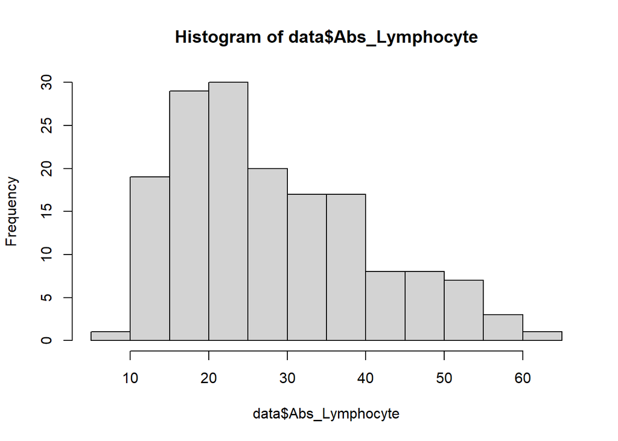

```r
# Create absolute lymphocyte estimate
data$Abs_Lymphocyte <- (data$Lymphocyte / 100) * data$total_wbc

# Inspect distribution
hist(data$Abs_Lymphocyte)
```

```r
# Optional square root transformation if skewed
data$sqrt_Abs_Lymphocyte <- sqrt(data$Abs_Lymphocyte)

# Fit model
m_abs_lymph <- glmmTMB(
  sqrt_Abs_Lymphocyte ~ Treatment + Body_mass + (1 | Tank_ID),
  family = gaussian(),
  data = data
)

summary(m_abs_lymph)
```

```
##  Family: gaussian  ( identity )
## Formula:          sqrt_Abs_Lymphocyte ~ Treatment + Body_mass + (1 | Tank_ID)
## Data: data
##
##      AIC      BIC   logLik deviance df.resid
##    386.0    404.4   -187.0    374.0      154
##
## Random effects:
##
## Conditional model:
##  Groups   Name        Variance Std.Dev.
##  Tank_ID  (Intercept) 0.08338  0.2888
##  Residual             0.54571  0.7387
## Number of obs: 160, groups:  Tank_ID, 24
##
## Dispersion estimate for gaussian family (sigma^2): 0.546
##
## Conditional model:
##               Estimate Std. Error z value Pr(>|z|)
## (Intercept)     6.4458     0.2332  27.637  < 2e-16 ***
## TreatmentLow   -1.8617     0.2033  -9.158  < 2e-16 ***
## TreatmentHigh  -1.2627     0.2033  -6.210 5.29e-10 ***
## Body_mass      -0.3631     0.3077  -1.180    0.238
## ---
## Signif. codes:  0 '***' 0.001 '**' 0.01 '*' 0.05 '.' 0.1 ' ' 1
```

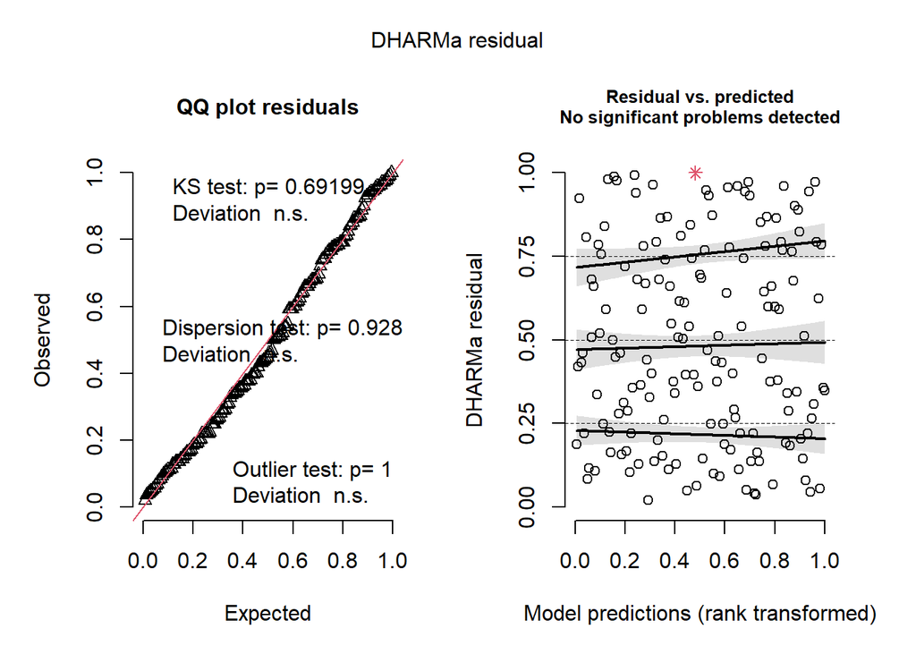

```r
# Diagnostics
res_abs_lymph <- DHARMa::simulateResiduals(m_abs_lymph)
plot(res_abs_lymph)
```

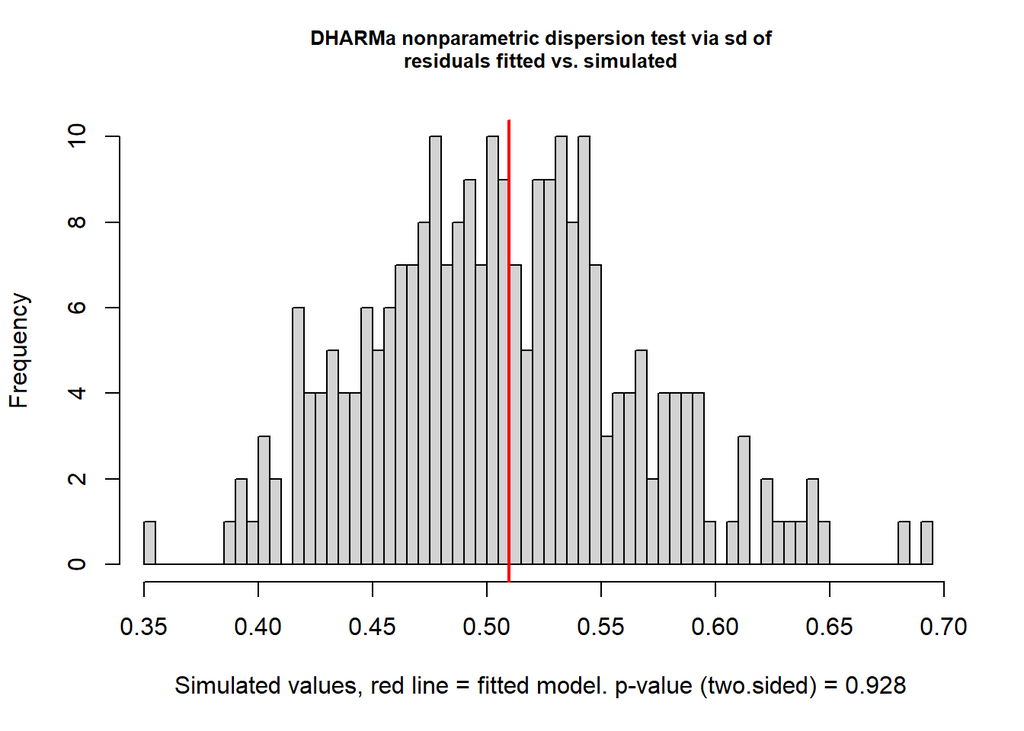

```
##
##  DHARMa nonparametric dispersion test via sd of residuals fitted vs.
##  simulated
##
## data:  simulationOutput
## dispersion = 1.0064, p-value = 0.928
## alternative hypothesis: two.sided
```

```r
DHARMa::testDispersion(res_abs_lymph)
```

```r
# Type II test
Anova(m_abs_lymph)
```

```
## Analysis of Deviance Table (Type II Wald chisquare tests)
##
## Response: sqrt_Abs_Lymphocyte
##             Chisq Df Pr(>Chisq)
## Treatment 87.4841  2     <2e-16 ***
## Body_mass  1.3932  1     0.2379
## ---
## Signif. codes:  0 '***' 0.001 '**' 0.01 '*' 0.05 '.' 0.1 ' ' 1
```

```r
# Estimated marginal means
emm_abs_lymph <- emmeans(m_abs_lymph, ~ Treatment)

pairs(emm_abs_lymph, adjust = "tukey")
```

```
##  contrast       estimate    SE  df t.ratio p.value
##  Control - Low     1.862 0.203 154   9.158  <.0001
##  Control - High    1.263 0.203 154   6.210  <.0001
##  Low - High       -0.599 0.204 154  -2.940  0.0105
##
## P value adjustment: tukey method for comparing a family of 3 estimates
```

# Analyse absolute neutrophil abundance

Estimate absolute neutrophil abundance from the neutrophil percentage and total white blood cell count.

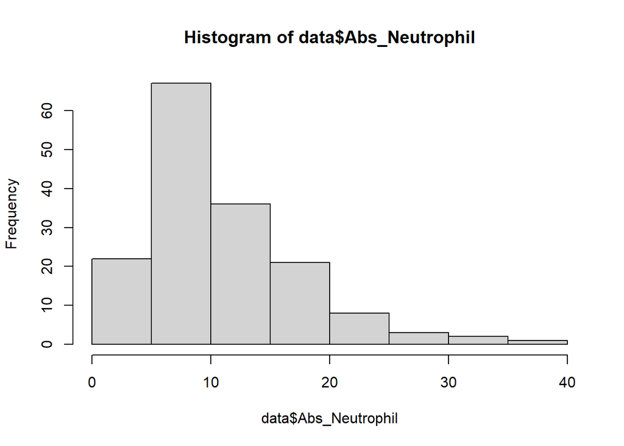

```r
# Create absolute neutrophil abundance
data$Abs_Neutrophil <- (data$Neutrophil / 100) * data$total_wbc

# Inspect distribution
hist(data$Abs_Neutrophil)
```

```r
# Square-root transformation
data$sqrt_Abs_Neutrophil <- sqrt(data$Abs_Neutrophil)

# Fit model
m_abs_neut <- glmmTMB(
  sqrt_Abs_Neutrophil ~ Treatment + Body_mass + (1 | Tank_ID),
  family = gaussian(),
  data = data
)

summary(m_abs_neut)
```

```
##  Family: gaussian  ( identity )
## Formula:          sqrt_Abs_Neutrophil ~ Treatment + Body_mass + (1 | Tank_ID)
## Data: data
##
##      AIC      BIC   logLik deviance df.resid
##    322.0    340.5   -155.0    310.0      154
##
## Random effects:
##
## Conditional model:
##  Groups   Name        Variance Std.Dev.
##  Tank_ID  (Intercept) 0.09722  0.3118
##  Residual             0.34707  0.5891
## Number of obs: 160, groups:  Tank_ID, 24
##
## Dispersion estimate for gaussian family (sigma^2): 0.347
##
## Conditional model:
##               Estimate Std. Error z value Pr(>|z|)
## (Intercept)     3.1950     0.2007  15.917  < 2e-16 ***
## TreatmentLow    1.0279     0.1932   5.320 1.04e-07 ***
## TreatmentHigh  -0.4310     0.1933  -2.230   0.0257 *
## Body_mass      -0.3727     0.2459  -1.515   0.1297
## ---
## Signif. codes:  0 '***' 0.001 '**' 0.01 '*' 0.05 '.' 0.1 ' ' 1
```

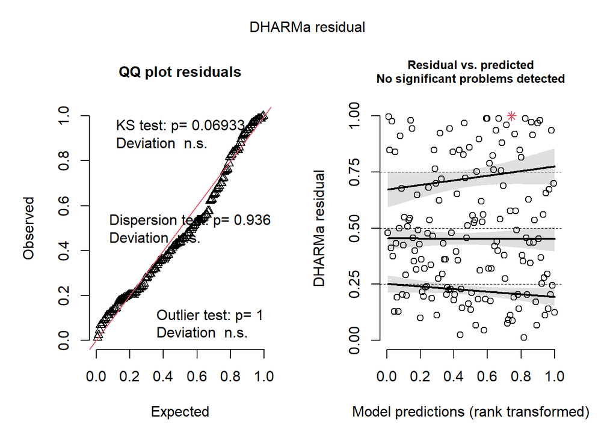

```r
# Residual diagnostics
res_abs_neut <- DHARMa::simulateResiduals(m_abs_neut)

plot(res_abs_neut)
```

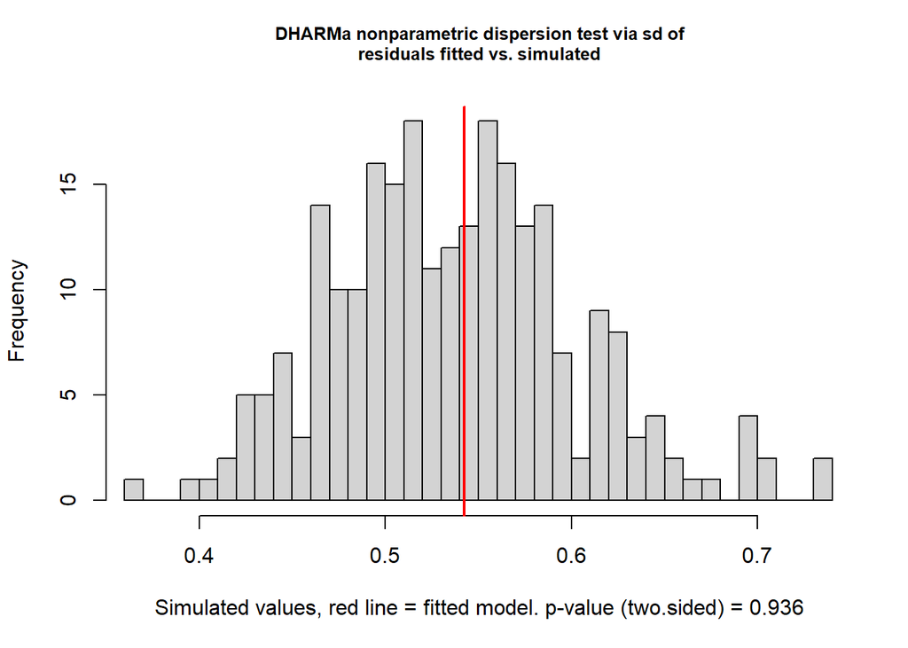

```
##
##  DHARMa nonparametric dispersion test via sd of residuals fitted vs.
##  simulated
##
## data:  simulationOutput
## dispersion = 1.0091, p-value = 0.936
## alternative hypothesis: two.sided
```

```r
DHARMa::testDispersion(res_abs_neut)
```

```r
# Type II Wald tests
Anova(m_abs_neut)
```

```
## Analysis of Deviance Table (Type II Wald chisquare tests)
##
## Response: sqrt_Abs_Neutrophil
##             Chisq Df Pr(>Chisq)
## Treatment 60.0164  2  9.281e-14 ***
## Body_mass  2.2967  1     0.1297
## ---
## Signif. codes:  0 '***' 0.001 '**' 0.01 '*' 0.05 '.' 0.1 ' ' 1
```

```r
# Estimated marginal means
emm_abs_neut <- emmeans(m_abs_neut, ~ Treatment)

pairs(emm_abs_neut, adjust = "tukey")
```

```
##  contrast       estimate    SE  df t.ratio p.value
##  Control - Low    -1.028 0.193 154  -5.320  <.0001
##  Control - High    0.431 0.193 154   2.230  0.0694
##  Low - High        1.459 0.194 154   7.538  <.0001
##
## P value adjustment: tukey method for comparing a family of 3 estimates
```

## Plot absolute lymphocyte and neutrophil abundance

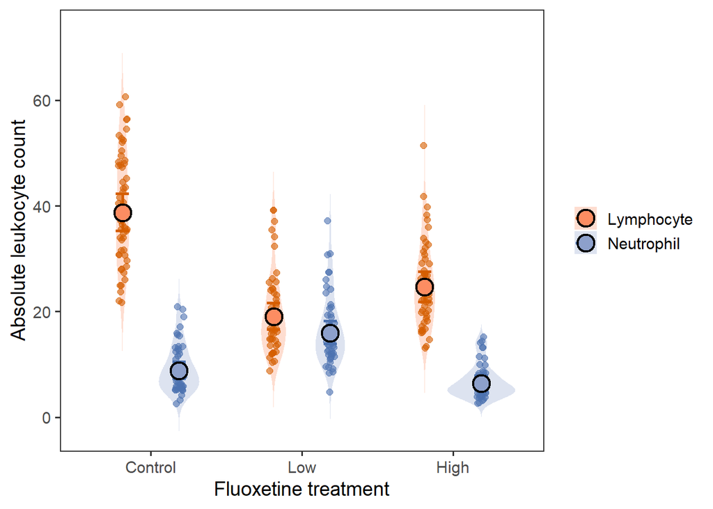

```r
# Plotting absolute lymphocytes and neutrophils

# Ensure treatment order
data$Treatment <- factor(
  data$Treatment,
  levels = c("Control", "Low", "High")
)

# ---------------------------
# 1) Long-format raw data
# ---------------------------
raw_abs_long <- data %>%
  dplyr::select(Treatment, Abs_Lymphocyte, Abs_Neutrophil) %>%
  tidyr::pivot_longer(
    cols = c(Abs_Lymphocyte, Abs_Neutrophil),
    names_to = "Cell_type",
    values_to = "Count"
  ) %>%
  dplyr::mutate(
    Cell_type = dplyr::recode(
      Cell_type,
      "Abs_Lymphocyte" = "Lymphocyte",
      "Abs_Neutrophil" = "Neutrophil"
    ),
    Cell_type = factor(
      Cell_type,
      levels = c("Lymphocyte", "Neutrophil")
    )
  )

# ---------------------------
# 2) Back-transformed model means
# ---------------------------
emm_lymph_abs <- emmeans(m_abs_lymph, ~ Treatment) %>%
  as.data.frame() %>%
  dplyr::transmute(
    Treatment = factor(
      Treatment,
      levels = c("Control", "Low", "High")
    ),
    Cell_type = factor(
      "Lymphocyte",
      levels = c("Lymphocyte", "Neutrophil")
    ),
    mean_count  = emmean^2,
    lower_count = lower.CL^2,
    upper_count = upper.CL^2
  )

emm_neut_abs <- emmeans(m_abs_neut, ~ Treatment) %>%
  as.data.frame() %>%
  dplyr::transmute(
    Treatment = factor(
      Treatment,
      levels = c("Control", "Low", "High")
    ),
    Cell_type = factor(
      "Neutrophil",
      levels = c("Lymphocyte", "Neutrophil")
    ),
    mean_count  = emmean^2,
    lower_count = lower.CL^2,
    upper_count = upper.CL^2
  )

emm_abs_both <- dplyr::bind_rows(
  emm_lymph_abs,
  emm_neut_abs
)

# ---------------------------
# 3) Colours
# ---------------------------
fill_cells <- c(
  "Lymphocyte" = "#FC8D62",
  "Neutrophil" = "#8DA0CB"
)

dark_cells <- c(
  "Lymphocyte" = "#D55E00",
  "Neutrophil" = "#4C72B0"
)

dodge_w <- 0.75

# ---------------------------
# 4) Plot
# ---------------------------
p_abs_lymphocyte_neutrophils <- ggplot(
  raw_abs_long,
  aes(x = Treatment, y = Count, fill = Cell_type)
) +

  geom_violin(
    position = position_dodge(width = dodge_w),
    alpha = 0.30,
    colour = NA,
    trim = FALSE
  ) +

  geom_jitter(
    aes(colour = Cell_type),
    position = position_jitterdodge(
      jitter.width = 0.12,
      dodge.width = dodge_w
    ),
    alpha = 0.6,
    size = 2
  ) +

  geom_errorbar(
    data = emm_abs_both,
    aes(
      x = Treatment,
      ymin = lower_count,
      ymax = upper_count,
      colour = Cell_type
    ),
    position = position_dodge(width = dodge_w),
    width = 0.18,
    linewidth = 1,
    inherit.aes = FALSE
  ) +

  geom_point(
    data = emm_abs_both,
    aes(
      x = Treatment,
      y = mean_count,
      fill = Cell_type
    ),
    shape = 21,
    size = 5,
    stroke = 1.2,
    colour = "black",
    position = position_dodge(width = dodge_w),
    inherit.aes = FALSE
  ) +

  scale_fill_manual(values = fill_cells) +
  scale_colour_manual(values = dark_cells) +

  theme_bw(base_size = 14) +

  labs(
    x = "Fluoxetine treatment",
    y = "Absolute leukocyte count"
  ) +

  theme(
    panel.grid = element_blank(),
    legend.title = element_blank()
  )

# Display
p_abs_lymphocyte_neutrophils
```

```r
# Save
ggsave(
  filename = here::here(
    "figures",
    "absolute_lymphocytes_neutrophils.pdf"
  ),
  plot = p_abs_lymphocyte_neutrophils,
  width = 6,
  height = 5
)

ggsave(
  filename = here::here(
    "figures",
    "absolute_lymphocytes_neutrophils.jpg"
  ),
  plot = p_abs_lymphocyte_neutrophils,
  width = 6,
  height = 5,
  dpi = 600
)
```

## Assemble the final immunity figure

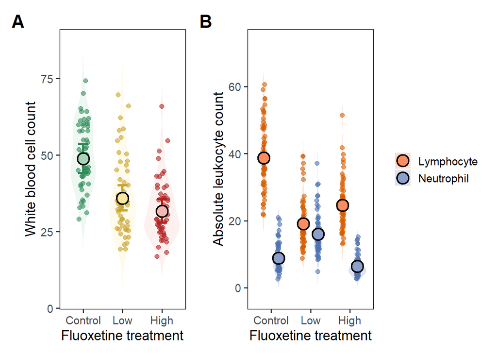

```r
# Layout:
# A | B

figure_immunity <- (
  p_wbc | p_abs_lymphocyte_neutrophils
) +
  plot_annotation(tag_levels = "A") &
  theme(
    plot.tag = element_text(
      size = 18,
      face = "bold"
    )
  )

# Display
figure_immunity
```

```r
ggsave(
  filename = here::here("figures", "immune_figure.pdf"),
  plot = figure_immunity,
  width = 9,
  height = 4.5
)

ggsave(
  filename = here::here("figures", "immune_figure.jpg"),
  plot = figure_immunity,
  width = 9,
  height = 4.5,
  dpi = 600
)
```